# PointingXP

Céline Coutrix / Papa Assane Fall

11/23/2023

## Loading libraries

```r
library(ggplot2)
```

## Loading data

```r
meanMTdf <- read.csv("../data/20211117_1527_MeanMT.csv", header=T)
rawdf <- read.csv("../data/20211117_1527_RawData.csv", header=T)
rawdf
```

```
##     A W   MT ID
## 1  16 1 1935  4
## 2  16 1 1338  4
## 3  16 1 1407  4
## 4  16 1 2092  4
## 5  16 1 1282  4
## 6  32 1 2621  5
## 7  32 1 2036  5
## 8  32 1 1733  5
## 9  32 1 1776  5
## 10 32 1 1239  5
## 11 32 2 1317  4
## 12 32 2 1271  4
## 13 32 2 1204  4
## 14 32 2 1114  4
```

[output cut: 31 more lines]

```r
meanMTdf
```

```
##    A W   MT ID
## 1 16 1 1611  4
## 2 32 1 1881  5
## 3 32 2 1276  4
## 4  8 4  949  2
## 5  8 1 1440  3
## 6 16 2 1586  3
## 7 32 4 1080  3
## 8  8 2 1870  2
## 9 16 4 1390  2
```

## Plotting the data together with the linear regression

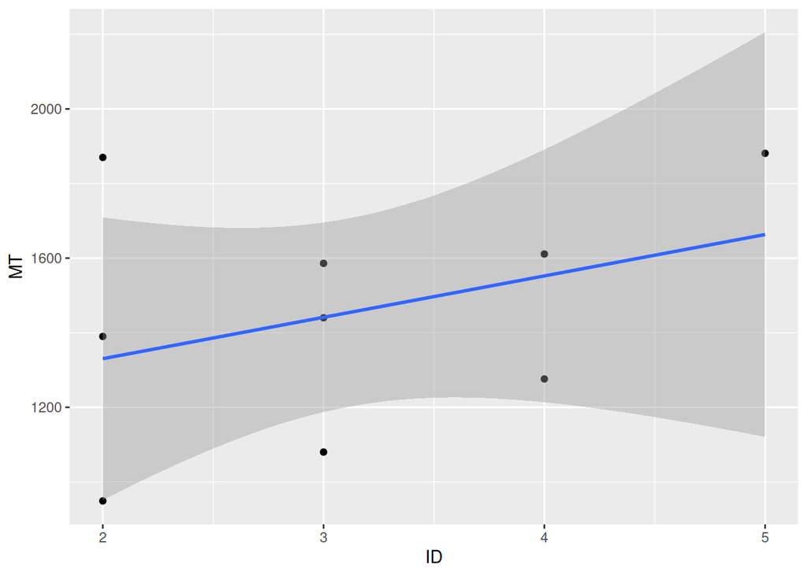

```r
ggplot(meanMTdf, aes(ID, MT)) +
  geom_point() +
  geom_smooth(method='lm')
```

## Linear modelling

```r
model <- lm(MT~ID, data = meanMTdf)
summary(model)
```

```
##
## Call:
## lm(formula = MT ~ ID, data = meanMTdf)
##
## Residuals:
##    Min     1Q Median     3Q    Max
## -381.4 -276.3   58.7  144.7  539.6
##
## Coefficients:
##             Estimate Std. Error t value Pr(>|t|)
## (Intercept)   1108.4      351.1   3.158    0.016 *
## ID             111.0      107.5   1.032    0.336
## ---
## Signif. codes:  0 '***' 0.001 '**' 0.01 '*' 0.05 '.' 0.1 ' ' 1
##
## Residual standard error: 320.5 on 7 degrees of freedom
## Multiple R-squared:  0.1321, Adjusted R-squared:  0.008146
## F-statistic: 1.066 on 1 and 7 DF,  p-value: 0.3363
```

Weirdly, in contrast to what Fitts’ law says, ID does not seem to have an impact on the movement time. Also, the R2=0.218 reported by the [experimental software](http://ergo.human.cornell.edu/FittsLaw/FittsLaw.html) and the R2=0.008146 I find here, are different.

Let us do some more experiments!

```r
meanMTdf <- read.csv("../data/20231116_1455_MeanMT.csv", header=T)
rawdf <- read.csv("../data/20231116_1454_RawData.csv", header=T)
rawdf
```

```
##     A W    MT ID
## 1  16 2  1717  3
## 2  16 2  1565  3
## 3  16 2  1044  3
## 4  16 2  1161  3
## 5  16 2  1250  3
## 6  16 4   829  2
## 7  16 4     0  2
## 8  16 4     0  2
## 9  16 4     0  2
## 10 16 4     0  2
## 11 64 4  1738  4
## 12 64 4  1662  4
## 13 64 4  1230  4
## 14 64 4  1417  4
```

[output cut: 31 more lines]

```r
meanMTdf
```

```
##    A W   MT ID
## 1 16 2 1347  3
## 2 16 4  166  2
## 3 64 4 1361  4
## 4 32 1 1510  5
## 5 32 2 1112  4
## 6 32 4 1283  3
## 7 64 2 1821  5
## 8 16 1 8164  4
## 9 64 1 1661  6
```

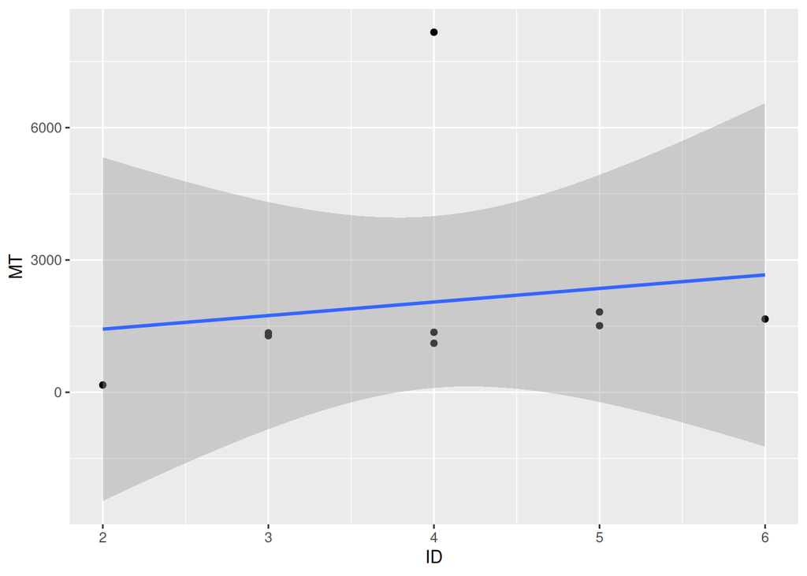

```r
ggplot(meanMTdf, aes(ID, MT)) +
  geom_point() +
  geom_smooth(method='lm')
```

```r
model <- lm(MT~ID, data = meanMTdf)
summary(model)
```

```
##
## Call:
## lm(formula = MT ~ ID, data = meanMTdf)
##
## Residuals:
##     Min      1Q  Median      3Q     Max
## -1266.1  -935.2  -686.2  -456.6  6116.8
##
## Coefficients:
##             Estimate Std. Error t value Pr(>|t|)
## (Intercept)    816.9     2969.3   0.275    0.791
## ID             307.6      713.2   0.431    0.679
##
## Residual standard error: 2471 on 7 degrees of freedom
## Multiple R-squared:  0.02588,    Adjusted R-squared:  -0.1133
## F-statistic: 0.186 on 1 and 7 DF,  p-value: 0.6792
```

First off, we quite tried to retrieve the code used behind [experimental software](http://ergo.human.cornell.edu/FittsLaw/FittsLaw.html) to compute RSquare, as we’re sure it is different from R’s LM. We imagine the fundamental differences are mainly focused on the person performing the task, the tool used, the environment they’re in and the conditions of the experiment (i.e. width, number of trials, competition on speed or precision, …).

Visibility (screen under direct sunlight in a bright day, colorblindness), training/rehearsal, and so many other minute microscopic reasons/causes to drastically different results!

The following’s the same experience, but with a phone (smaller but tactile screen).

```r
meanMTdf <- read.csv("../data/20231116_1557_MeanMT.csv", header=T)
rawdf <- read.csv("../data/20231116_1557_RawData.csv", header=T)
rawdf
```

```
##     X X.1 X.2 X.3
## 1   A   W  MT  ID
## 2  32   1 780   5
## 3  32   1 844   5
## 4  32   1 647   5
## 5  32   1 777   5
## 6  32   1 714   5
## 7  16   4   0   2
## 8  16   4 687   2
## 9  16   4 669   2
## 10 16   4 636   2
## 11 16   4 583   2
## 12 64   2 730   5
## 13 64   2 666   5
## 14 64   2 707   5
```

[output cut: 32 more lines]

```r
meanMTdf
```

```
##    A W  MT ID
## 1 32 1 752  5
## 2 16 4 515  2
## 3 64 2 688  5
## 4 64 1 621  6
## 5 32 4 625  3
## 6 16 2 595  3
## 7 16 1 587  4
## 8 64 4 635  4
## 9 32 2 572  4
```

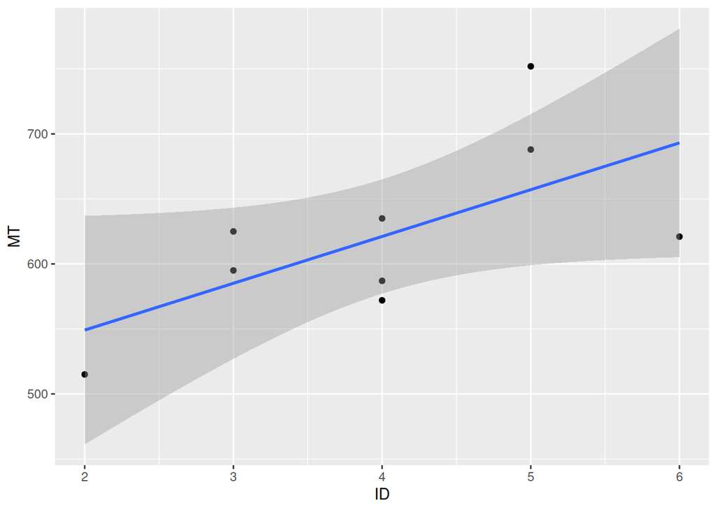

```r
ggplot(meanMTdf, aes(ID, MT)) +
  geom_point() +
  geom_smooth(method='lm')
```

```r
model <- lm(MT~ID, data = meanMTdf)
summary(model)
```

```
##
## Call:
## lm(formula = MT ~ ID, data = meanMTdf)
##
## Residuals:
##     Min      1Q  Median      3Q     Max
## -72.111 -34.111   9.889  30.889  94.889
##
## Coefficients:
##             Estimate Std. Error t value Pr(>|t|)
## (Intercept)   477.11      67.04   7.117 0.000191 ***
## ID             36.00      16.10   2.236 0.060455 .
## ---
## Signif. codes:  0 '***' 0.001 '**' 0.01 '*' 0.05 '.' 0.1 ' ' 1
##
## Residual standard error: 55.78 on 7 degrees of freedom
## Multiple R-squared:  0.4166, Adjusted R-squared:  0.3333
## F-statistic: 4.999 on 1 and 7 DF,  p-value: 0.06046
```

Now with a tablet (bigger (now similar than the first gadget) and tactile screen) :

```r
meanMTdf <- read.csv("../data/20231116_1705_MeanMT.csv", header=T)
rawdf <- read.csv("../data/20231116_1705_RawData.csv", header=T)
rawdf
```

```
##     A W  MT ID
## 1  16 2 513  3
## 2  16 2 460  3
## 3  16 2 463  3
## 4  16 2 520  3
## 5  16 2 458  3
## 6  32 2 488  4
## 7  32 2 463  4
## 8  32 2 524  4
## 9  32 2 604  4
## 10 32 2 495  4
## 11 32 4 525  3
## 12 32 4 497  3
## 13 32 4 494  3
## 14 32 4 482  3
```

[output cut: 31 more lines]

```r
meanMTdf
```

```
##    A W  MT ID
## 1 16 2 483  3
## 2 32 2 515  4
## 3 32 4 494  3
## 4 16 1 547  4
## 5 64 2 549  5
## 6 16 4 435  2
## 7 32 1 552  5
## 8 64 4 536  4
## 9 64 1 590  6
```

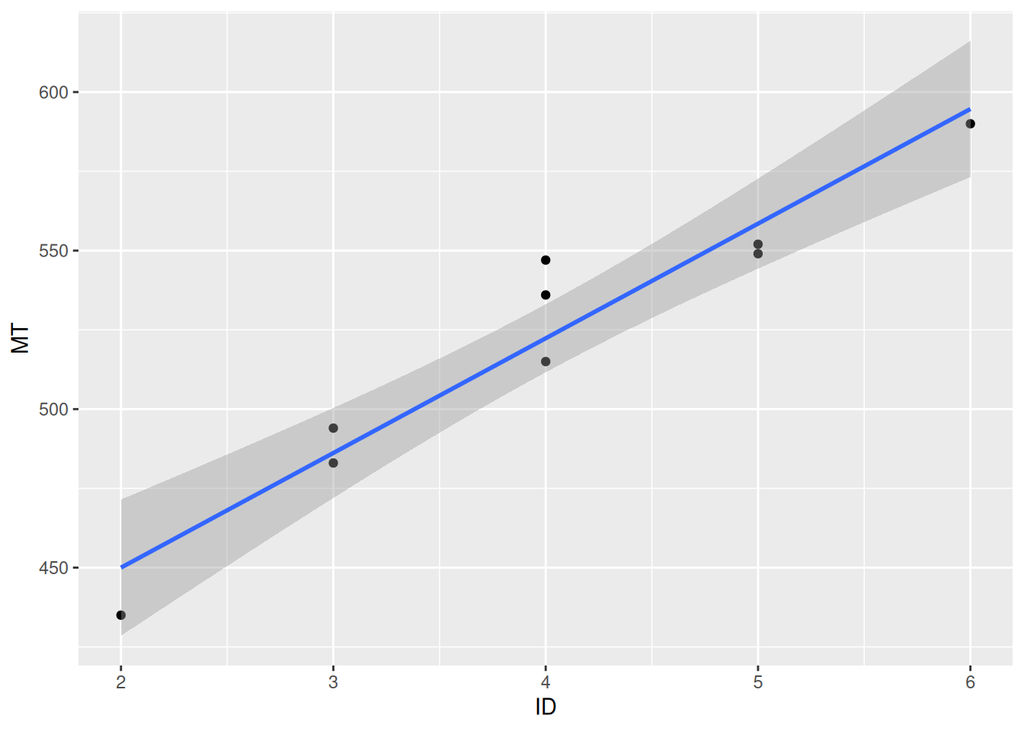

```r
ggplot(meanMTdf, aes(ID, MT)) +
  geom_point() +
  geom_smooth(method='lm')
```

```r
model <- lm(MT~ID, data = meanMTdf)
summary(model)
```

```
##
## Call:
## lm(formula = MT ~ ID, data = meanMTdf)
##
## Residuals:
##     Min      1Q  Median      3Q     Max
## -15.000  -7.333  -4.667   7.833  24.667
##
## Coefficients:
##             Estimate Std. Error t value Pr(>|t|)
## (Intercept)  377.667     16.376  23.062 7.31e-08 ***
## ID            36.167      3.933   9.195 3.71e-05 ***
## ---
## Signif. codes:  0 '***' 0.001 '**' 0.01 '*' 0.05 '.' 0.1 ' ' 1
##
## Residual standard error: 13.63 on 7 degrees of freedom
## Multiple R-squared:  0.9235, Adjusted R-squared:  0.9126
## F-statistic: 84.54 on 1 and 7 DF,  p-value: 3.711e-05
```

Got 1 pointing error count (yay?.. the error was quite on purpose ^^’.. okay, still a noob -_-), without any change in the configuration… software reported R2=0.912 (great model accuracy! (and MT = 363.070 + 38.703(A/W + 1))), found R2=0.9235 (ohw, now it is much closer to the adjusted one, with 0.9126… why..?).